# Nexo entre crecimiento económico y desarrollo del sistema financiero: análisis de cointegración y series de tiempo, para el caso de Costa Rica.

Fabián Brenes Trejos

16/5/2021

El objetivo del estudio consiste en estudiar la relación entre el **crecimiento económico** (representado por el PIB real) y el **desarrollo del sistema financiero** (se utiliza como variable proxy los créditos al sector privado en porcentajes del PIB nominal), mediante modelos multivariados temporales.

## PIB Real de Costa Rica

- Fuente primaria: Banco Central de Costa Rica
- Unidad de medida: Crecimiento interanual

[interactive chart not shown]

### Análisis de Estacionariedad serie original

Con base a la prueba Dickey-Fuller y al correlograma se concluye que la **serie es no estacionaria**.

```
##
## ###############################################
## # Augmented Dickey-Fuller Test Unit Root Test #
## ###############################################
##
## Test regression trend
##
##
## Call:
## lm(formula = z.diff ~ z.lag.1 + 1 + tt + z.diff.lag)
##
## Residuals:
##       Min        1Q    Median        3Q       Max
## -0.090899 -0.007370  0.001551  0.011216  0.035086
##
## Coefficients:
##               Estimate Std. Error t value Pr(>|t|)
## (Intercept)  0.0175430  0.0061906   2.834 0.005853 **
## z.lag.1     -0.3006258  0.0878589  -3.422 0.000994 ***
## tt          -0.0001670  0.0000908  -1.839 0.069707 .
## z.diff.lag   0.1268108  0.1205913   1.052 0.296242
## ---
## Signif. codes:  0 '***' 0.001 '**' 0.01 '*' 0.05 '.' 0.1 ' ' 1
##
## Residual standard error: 0.01826 on 78 degrees of freedom
## Multiple R-squared:  0.1382, Adjusted R-squared:  0.1051
## F-statistic:  4.17 on 3 and 78 DF,  p-value: 0.008583
##
##
## Value of test-statistic is: -3.4217 4.139 6.1228
##
## Critical values for test statistics:
##       1pct  5pct 10pct
## tau3 -4.04 -3.45 -3.15
## phi2  6.50  4.88  4.16
## phi3  8.73  6.49  5.47
```

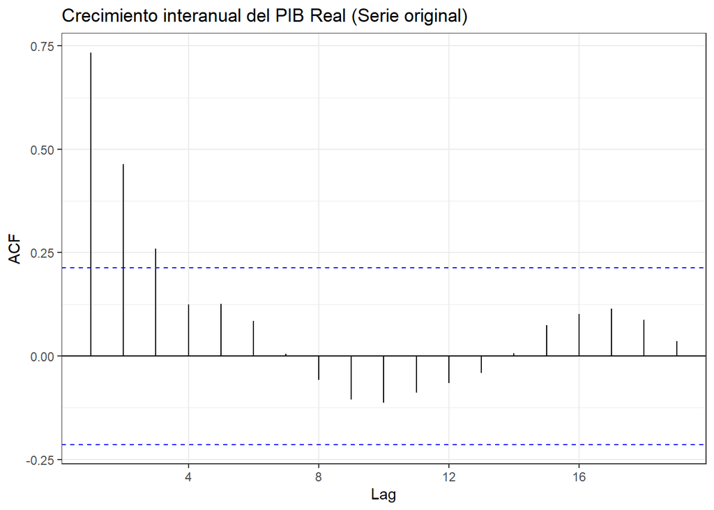

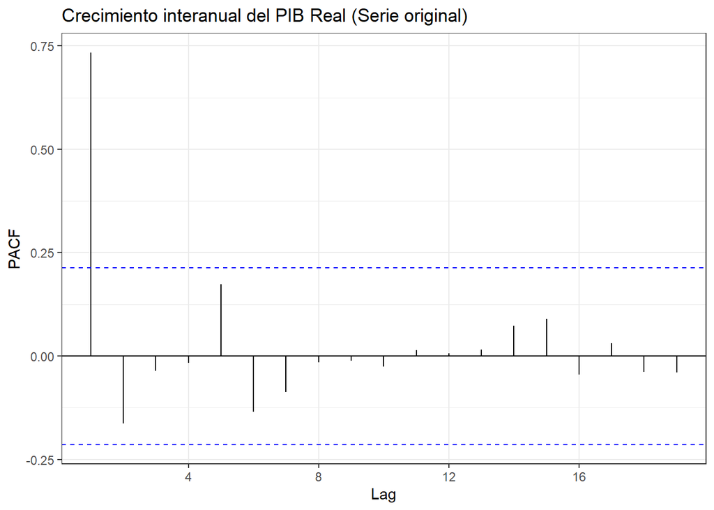

### Estacionariedad serie en primeras diferencias

Con el autocorrelograma y la prueba Dickey-Fuller se comprueba que el crecimiento interanual del PIB real de Costa Rica es estacionario de orden 1.

```
##
## ###############################################
## # Augmented Dickey-Fuller Test Unit Root Test #
## ###############################################
##
## Test regression none
##
##
## Call:
## lm(formula = z.diff ~ z.lag.1 - 1 + z.diff.lag)
##
## Residuals:
##      Min       1Q   Median       3Q      Max
## -0.09140 -0.01238  0.00071  0.01015  0.04233
##
## Coefficients:
##            Estimate Std. Error t value Pr(>|t|)
## z.lag.1     -1.2711     0.1656  -7.676 3.72e-11 ***
## z.diff.lag   0.2055     0.1127   1.823    0.072 .
## ---
## Signif. codes:  0 '***' 0.001 '**' 0.01 '*' 0.05 '.' 0.1 ' ' 1
##
## Residual standard error: 0.01913 on 79 degrees of freedom
## Multiple R-squared:  0.5334, Adjusted R-squared:  0.5216
## F-statistic: 45.16 on 2 and 79 DF,  p-value: 8.35e-14
##
##
## Value of test-statistic is: -7.6759
##
## Critical values for test statistics:
##      1pct  5pct 10pct
## tau1 -2.6 -1.95 -1.61
```

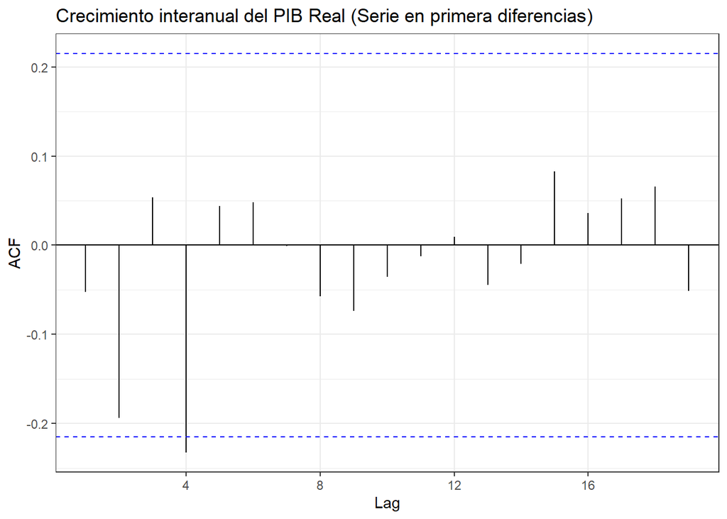

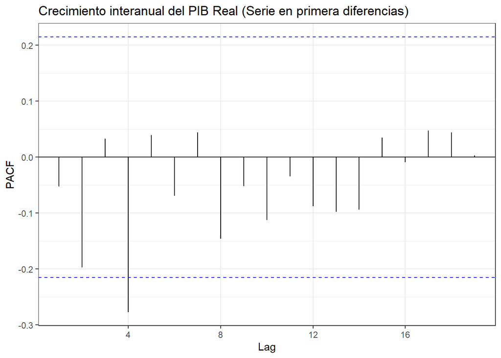

## Créditos al sector privado

- Fuente primaria: Banco Central de Costa Rica
- Unidad de medida: Porcentaje del PIB nominal

[interactive chart not shown]

### Estacionariedad serie original

Con base a la prueba Dickey Fuller, no existe suficiente evidencia estadística para rechazar la hipótesis nula de que la serie es no estacionaria, con un nivel de significancia del 1%. De igual manera, con el correlograma de la serie se concluye lo mismo, por tanto la **serie es no estacionaria de orden 0**.

```
##
## ###############################################
## # Augmented Dickey-Fuller Test Unit Root Test #
## ###############################################
##
## Test regression trend
##
##
## Call:
## lm(formula = z.diff ~ z.lag.1 + 1 + tt + z.diff.lag)
##
## Residuals:
##        Min         1Q     Median         3Q        Max
## -0.0258400 -0.0050351  0.0005978  0.0056495  0.0173791
##
## Coefficients:
##               Estimate Std. Error t value Pr(>|t|)
## (Intercept)  0.0241461  0.0088960   2.714 0.008173 **
## z.lag.1     -0.0832442  0.0353007  -2.358 0.020872 *
## tt           0.0003426  0.0001594   2.149 0.034750 *
## z.diff.lag   0.4205232  0.1035519   4.061 0.000115 ***
## ---
## Signif. codes:  0 '***' 0.001 '**' 0.01 '*' 0.05 '.' 0.1 ' ' 1
##
## Residual standard error: 0.007959 on 78 degrees of freedom
## Multiple R-squared:  0.2073, Adjusted R-squared:  0.1768
## F-statistic: 6.799 on 3 and 78 DF,  p-value: 0.0003937
##
##
## Value of test-statistic is: -2.3581 4.4289 2.9664
##
## Critical values for test statistics:
##       1pct  5pct 10pct
## tau3 -4.04 -3.45 -3.15
## phi2  6.50  4.88  4.16
## phi3  8.73  6.49  5.47
```

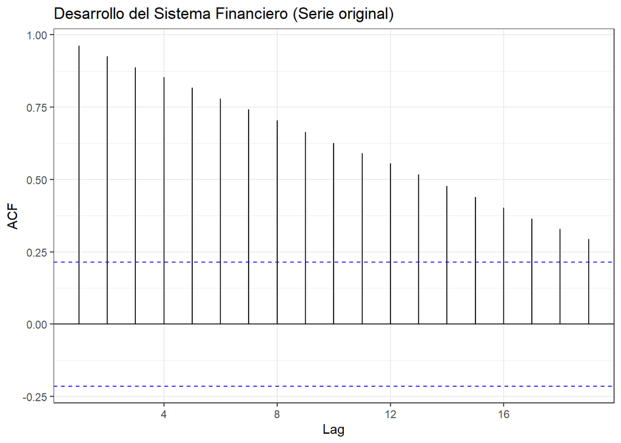

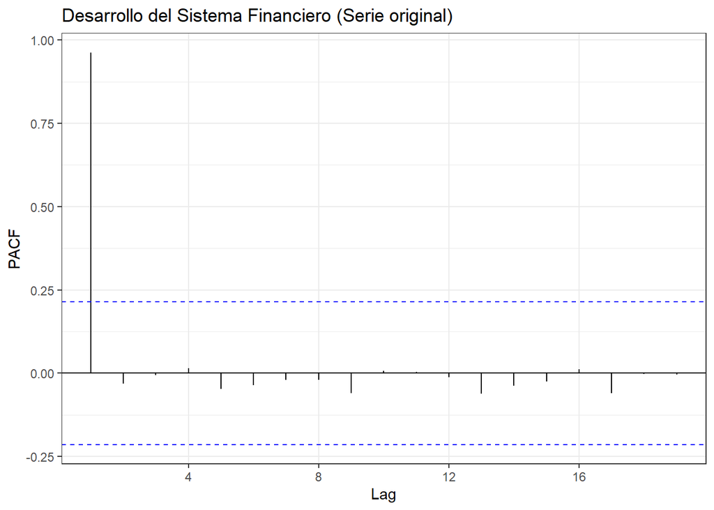

### Estacionariedad serie en primeras diferencias

Tanto con la prueba Dickey Fuller, en donde existe evidencia estadística para rechazar la hipótesis nula de que la serie en primeras diferencias es no estacionaria con un nivel de significancia del 1%, como con el autocorrelograma, se concluye que la serie en primeras diferencias es estacionario, es decir, el desarrollo del sistema financiero es **estacionaria de orden 1**

```
##
## ###############################################
## # Augmented Dickey-Fuller Test Unit Root Test #
## ###############################################
##
## Test regression none
##
##
## Call:
## lm(formula = z.diff ~ z.lag.1 - 1 + z.diff.lag)
##
## Residuals:
##       Min        1Q    Median        3Q       Max
## -0.026633 -0.003109  0.003224  0.007219  0.016845
##
## Coefficients:
##            Estimate Std. Error t value Pr(>|t|)
## z.lag.1     -0.4306     0.1129  -3.814  0.00027 ***
## z.diff.lag  -0.1291     0.1132  -1.141  0.25752
## ---
## Signif. codes:  0 '***' 0.001 '**' 0.01 '*' 0.05 '.' 0.1 ' ' 1
##
## Residual standard error: 0.008485 on 79 degrees of freedom
## Multiple R-squared:  0.2587, Adjusted R-squared:  0.2399
## F-statistic: 13.78 on 2 and 79 DF,  p-value: 7.333e-06
##
##
## Value of test-statistic is: -3.8138
##
## Critical values for test statistics:
##      1pct  5pct 10pct
## tau1 -2.6 -1.95 -1.61
```

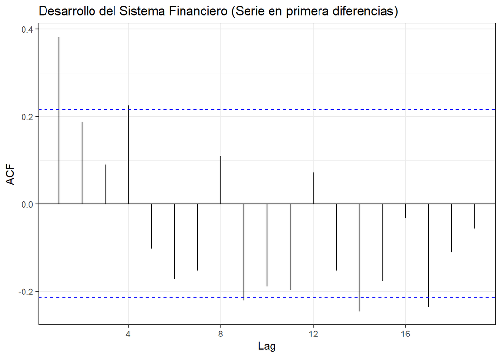

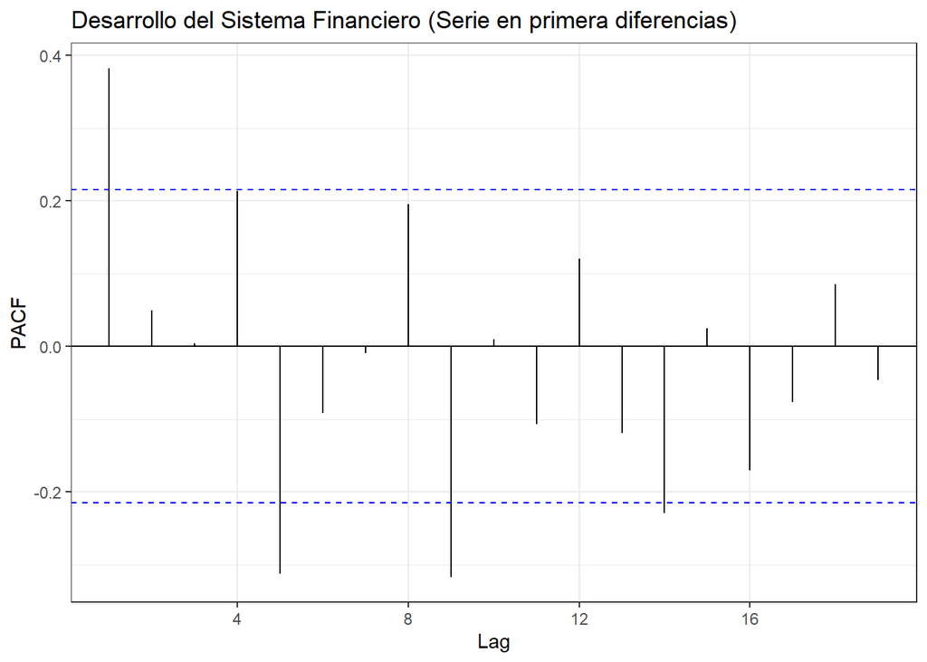

## Análisis Descriptivo

### Correlación entre crecimiento del PIBr y créditos al sector privado

[interactive chart not shown]

Las variables muestran un nivel de correlación de -0.35.

Al correr una regresión lineal simple entre el crecimiento del PIB real en función del desarrollo del sistema financiero y gráficar los residuos estandarizados, se observan que en el periodo de la crisis financiera mundial (2008 y 2009), estos valores son mayor a 2 en valor absoluto. De igual manera, para diciembre 2019 el residuo estandarizado es mayor a 2.

### Variables de control

[output not shown]

* Fuente: Banco Central de Costa Rica

### Gráficos de las Variables en Niveles

[interactive chart not shown]

### Gráficos de Dispersión vrs crecimiento del PIBr

[interactive chart not shown]

### Gráficos de Dispersión vrs Desarrollo del Sistema Financiero

[interactive chart not shown]

### Regresión Lineal (variable dependiente = PIBr)

Ecuación: pibr_yoy ~ cred_pib+apert_comercial+ied+mif+pibusa

```r
mod_lm_pib <- lm(formula_mod_lineal_pib, data = data)
summary(mod_lm_pib)
```

```
##
## Call:
## lm(formula = formula_mod_lineal_pib, data = data)
##
## Residuals:
##      Min       1Q   Median       3Q      Max
## -0.07428 -0.01286  0.00262  0.01587  0.03622
##
## Coefficients:
##                   Estimate Std. Error t value Pr(>|t|)
## (Intercept)     -1.806e-01  9.415e-02  -1.918 0.058778 .
## cred_pib        -8.892e-02  1.167e-01  -0.762 0.448448
## apert_comercial  1.082e-03  3.959e-04   2.732 0.007784 **
## ied              5.182e-05  1.394e-05   3.717 0.000378 ***
## mif              9.589e-03  8.914e-03   1.076 0.285361
## pibusa           5.534e-06  4.813e-06   1.150 0.253724
## ---
## Signif. codes:  0 '***' 0.001 '**' 0.01 '*' 0.05 '.' 0.1 ' ' 1
##
## Residual standard error: 0.02312 on 78 degrees of freedom
## Multiple R-squared:  0.3698, Adjusted R-squared:  0.3294
## F-statistic: 9.155 on 5 and 78 DF,  p-value: 6.952e-07
```

#### Evaluación de los supuestos del modelo

##### 1. Multicolinealidad

```r
vif(mod_lm_pib)
```

```
##        cred_pib apert_comercial             ied             mif          pibusa
##       25.304139        2.937413        1.783875       10.362902       11.423138
```

##### 2. Homocedasticidad

```r
bptest(mod_lm_pib)
```

```
##
##  studentized Breusch-Pagan test
##
## data:  mod_lm_pib
## BP = 10.709, df = 5, p-value = 0.05747
```

##### 3. Autocorrelación en los residuos

El modelo presenta autocorrelación en el residuo.

```r
bgtest(mod_lm_pib)
```

```
##
##  Breusch-Godfrey test for serial correlation of order up to 1
##
## data:  mod_lm_pib
## LM test = 31.881, df = 1, p-value = 1.639e-08
```

##### 4. Normalidad de los residuos

Los residuos del modelo no siguen una distribución normal, con base a la prueba de Shapiro.

```r
shapiro.test(mod_lm_pib$residuals)
```

```
##
##  Shapiro-Wilk normality test
##
## data:  mod_lm_pib$residuals
## W = 0.93899, p-value = 0.000609
```

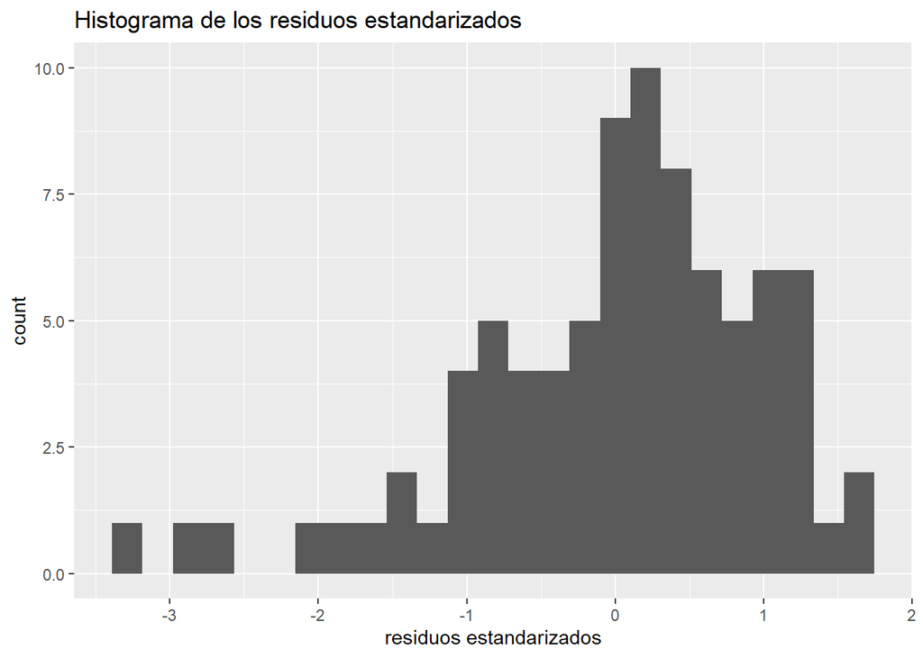

```r
tibble(`residuos estandarizados` = scale(mod_lm_pib$residuals)) %>%
  ggplot(aes(x = `residuos estandarizados`)) + geom_histogram(bins = 25) +
  ggtitle("Histograma de los residuos estandarizados")
```

### Regresión Lineal (variable dependiente = desarrollo del sistema financiero)

Ecuación: cred_pib ~ pibr_yoy +apert_comercial+ied+mif+pibusa

```r
mod_lm_dsf <- lm(formula_mod_lineal_dsf, data = data)
summary(mod_lm_dsf)
```

```
##
## Call:
## lm(formula = formula_mod_lineal_dsf, data = data)
##
## Residuals:
##       Min        1Q    Median        3Q       Max
## -0.044415 -0.014970  0.001121  0.008764  0.072188
##
## Coefficients:
##                   Estimate Std. Error t value Pr(>|t|)
## (Intercept)      3.121e-01  8.616e-02   3.622 0.000518 ***
## pibr_yoy        -8.307e-02  1.090e-01  -0.762 0.448448
## apert_comercial -7.700e-04  3.910e-04  -1.969 0.052453 .
## ied              1.394e-05  1.454e-05   0.959 0.340700
## mif             -4.902e-02  6.674e-03  -7.344 1.73e-10 ***
## pibusa           3.109e-05  3.101e-06  10.025 1.13e-15 ***
## ---
## Signif. codes:  0 '***' 0.001 '**' 0.01 '*' 0.05 '.' 0.1 ' ' 1
##
## Residual standard error: 0.02235 on 78 degrees of freedom
## Multiple R-squared:  0.9608, Adjusted R-squared:  0.9583
## F-statistic: 382.1 on 5 and 78 DF,  p-value: < 2.2e-16
```

#### Evaluación de los supuestos del modelo

##### 1. Multicolinealidad

Las covariables no presentan una alta multicolinealidad.

```r
vif(mod_lm_dsf)
```

```
##        pibr_yoy apert_comercial             ied             mif          pibusa
##        1.575122        3.066020        2.075339        6.217159        5.076152
```

##### 2. Homocedasticidad

```r
bptest(mod_lm_dsf)
```

```
##
##  studentized Breusch-Pagan test
##
## data:  mod_lm_dsf
## BP = 17.599, df = 5, p-value = 0.003494
```

##### 3. Autocorrelación en los residuos

El modelo presenta autocorrelación en el residuo.

```r
bgtest(mod_lm_dsf)
```

```
##
##  Breusch-Godfrey test for serial correlation of order up to 1
##
## data:  mod_lm_dsf
## LM test = 42.029, df = 1, p-value = 8.995e-11
```

##### 4. Normalidad de los residuos

Los residuos del modelo no siguen una distribución normal.

```r
shapiro.test(mod_lm_dsf$residuals)
```

```
##
##  Shapiro-Wilk normality test
##
## data:  mod_lm_dsf$residuals
## W = 0.96342, p-value = 0.01738
```

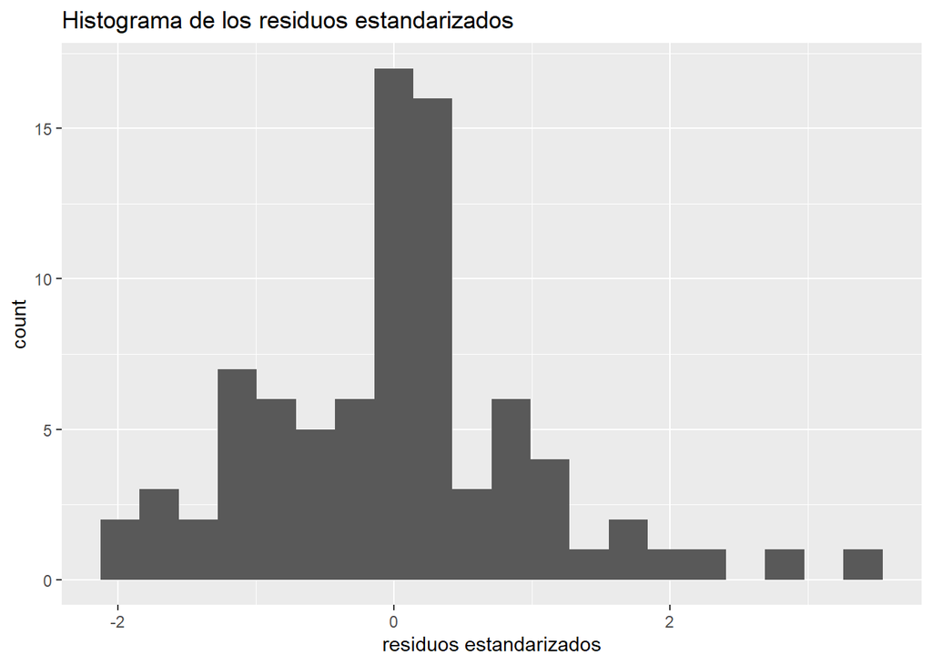

```r
tibble(`residuos estandarizados` = scale(mod_lm_dsf$residuals)) %>%
  ggplot(aes(x = `residuos estandarizados`)) + geom_histogram(bins = 20) +
  ggtitle("Histograma de los residuos estandarizados")
```

## Cointegración

### Cointegración entre Crecimiento del PIB real y Cred

Con base a la prueba de Johansen-Juselius, se rechaza la hipótesis nula de que no existe cointegración entre las variables, con un nivel de significancia del 5%.

```r
ca.jo(data %>% dplyr::select(pibr_yoy, cred_pib), type = "eigen",
      season = 4,
      K = 2, ecdet = "const") %>%
  summary()
```

```
##
## ######################
## # Johansen-Procedure #
## ######################
##
## Test type: maximal eigenvalue statistic (lambda max) , without linear trend and constant in cointegration
##
## Eigenvalues (lambda):
## [1] 1.794253e-01 7.714277e-02 1.110223e-16
##
## Values of teststatistic and critical values of test:
##
##           test 10pct  5pct  1pct
## r <= 1 |  6.58  7.52  9.24 12.97
## r = 0  | 16.22 13.75 15.67 20.20
##
## Eigenvectors, normalised to first column:
## (These are the cointegration relations)
##
##             pibr_yoy.l2 cred_pib.l2   constant
## pibr_yoy.l2  1.00000000   1.0000000  1.0000000
## cred_pib.l2  0.03527746   0.3898850 -0.9751245
## constant    -0.03816230  -0.2508301  0.3013972
##
## Weights W:
## (This is the loading matrix)
##
##            pibr_yoy.l2 cred_pib.l2      constant
## pibr_yoy.d -0.20441519 -0.07187166  2.759922e-18
## cred_pib.d  0.09772491 -0.01594529 -2.604635e-17
```

```r
ca.jo(data %>% dplyr::select(pibr_yoy, cred_pib), type = "trace",
      season = 4,
      K = 2, ecdet = "const") %>%
  summary()
```

```
##
## ######################
## # Johansen-Procedure #
## ######################
##
## Test type: trace statistic , without linear trend and constant in cointegration
##
## Eigenvalues (lambda):
## [1] 1.794253e-01 7.714277e-02 1.110223e-16
##
## Values of teststatistic and critical values of test:
##
##           test 10pct  5pct  1pct
## r <= 1 |  6.58  7.52  9.24 12.97
## r = 0  | 22.80 17.85 19.96 24.60
##
## Eigenvectors, normalised to first column:
## (These are the cointegration relations)
##
##             pibr_yoy.l2 cred_pib.l2   constant
## pibr_yoy.l2  1.00000000   1.0000000  1.0000000
## cred_pib.l2  0.03527746   0.3898850 -0.9751245
## constant    -0.03816230  -0.2508301  0.3013972
##
## Weights W:
## (This is the loading matrix)
##
##            pibr_yoy.l2 cred_pib.l2      constant
## pibr_yoy.d -0.20441519 -0.07187166  2.759922e-18
## cred_pib.d  0.09772491 -0.01594529 -2.604635e-17
```

### Cointegración entre todas las variables

Con base a la prueba de Johansen-Juselius, no existe evidencia suficiente para rechazar la hipótesis nula de que no existe cointegración entre las variables, con un nivel de significancia del 5%.

```r
ca.jo(data %>% dplyr::select(pibr_yoy, cred_pib, mif, pibusa_yoy, apert_comercial),
      type = "eigen",
      season = 4,
      K = 2, ecdet = "const") %>%
  summary()
```

```
##
## ######################
## # Johansen-Procedure #
## ######################
##
## Test type: maximal eigenvalue statistic (lambda max) , without linear trend and constant in cointegration
##
## Eigenvalues (lambda):
## [1] 2.481460e-01 1.802607e-01 1.658143e-01 1.104598e-01 7.558143e-02
## [6] 4.163336e-16
##
## Values of teststatistic and critical values of test:
##
##           test 10pct  5pct  1pct
## r <= 4 |  6.44  7.52  9.24 12.97
## r <= 3 |  9.60 13.75 15.67 20.20
## r <= 2 | 14.87 19.77 22.00 26.81
## r <= 1 | 16.30 25.56 28.14 33.24
## r = 0  | 23.39 31.66 34.40 39.79
##
## Eigenvectors, normalised to first column:
## (These are the cointegration relations)
##
##                     pibr_yoy.l2   cred_pib.l2       mif.l2 pibusa_yoy.l2
## pibr_yoy.l2         1.000000000  1.0000000000  1.000000000   1.000000000
## cred_pib.l2        -0.656373833  0.1710274006  0.631896903  -0.598967485
## mif.l2             -0.081806794  0.0133097317  0.100321925  -0.043976391
## pibusa_yoy.l2      -1.274117704  2.1111671324 -1.187371346  -0.692680477
## apert_comercial.l2  0.000664293 -0.0006603532 -0.002506671  -0.004452238
## constant            0.786188550 -0.1816619153 -0.752356885   0.840787453
##                    apert_comercial.l2      constant
## pibr_yoy.l2               1.000000000  1.0000000000
## cred_pib.l2               0.348588785 -0.3613055193
## mif.l2                   -0.031803635 -0.0035620305
## pibusa_yoy.l2            -0.987441436 -1.1452858734
## apert_comercial.l2        0.004136807  0.0009130714
## constant                 -0.283219388  0.0668955540
##
## Weights W:
## (This is the loading matrix)
##
##                    pibr_yoy.l2 cred_pib.l2      mif.l2 pibusa_yoy.l2
## pibr_yoy.d          0.02187673 -0.08416967 -0.06696440   -0.01082826
## cred_pib.d          0.06605710  0.03227431  0.01564462    0.01328429
## mif.d               0.74622882 -0.39296200 -2.83591575    0.40161603
## pibusa_yoy.d        0.05815857 -0.09738711  0.01891683    0.05369342
## apert_comercial.d -15.24470487 -3.39831221 -9.73073430   25.08281339
##                   apert_comercial.l2      constant
## pibr_yoy.d               -0.07457865 -3.857205e-16
## cred_pib.d               -0.01443345 -1.998639e-16
## mif.d                     0.39065997 -1.000413e-14
## pibusa_yoy.d             -0.01849092 -3.713445e-16
## apert_comercial.d        -8.86709722 -1.076357e-13
```

```r
ca.jo(data %>% dplyr::select(pibr_yoy, cred_pib, mif, pibusa_yoy, apert_comercial),
      type = "trace",
      season = 4,
      K = 2, ecdet = "const") %>%
  summary()
```

```
##
## ######################
## # Johansen-Procedure #
## ######################
##
## Test type: trace statistic , without linear trend and constant in cointegration
##
## Eigenvalues (lambda):
## [1] 2.481460e-01 1.802607e-01 1.658143e-01 1.104598e-01 7.558143e-02
## [6] 4.163336e-16
##
## Values of teststatistic and critical values of test:
##
##           test 10pct  5pct  1pct
## r <= 4 |  6.44  7.52  9.24 12.97
## r <= 3 | 16.04 17.85 19.96 24.60
## r <= 2 | 30.91 32.00 34.91 41.07
## r <= 1 | 47.21 49.65 53.12 60.16
## r = 0  | 70.60 71.86 76.07 84.45
##
## Eigenvectors, normalised to first column:
## (These are the cointegration relations)
##
##                     pibr_yoy.l2   cred_pib.l2       mif.l2 pibusa_yoy.l2
## pibr_yoy.l2         1.000000000  1.0000000000  1.000000000   1.000000000
## cred_pib.l2        -0.656373833  0.1710274006  0.631896903  -0.598967485
## mif.l2             -0.081806794  0.0133097317  0.100321925  -0.043976391
## pibusa_yoy.l2      -1.274117704  2.1111671324 -1.187371346  -0.692680477
## apert_comercial.l2  0.000664293 -0.0006603532 -0.002506671  -0.004452238
## constant            0.786188550 -0.1816619153 -0.752356885   0.840787453
##                    apert_comercial.l2      constant
## pibr_yoy.l2               1.000000000  1.0000000000
## cred_pib.l2               0.348588785 -0.3613055193
## mif.l2                   -0.031803635 -0.0035620305
## pibusa_yoy.l2            -0.987441436 -1.1452858734
## apert_comercial.l2        0.004136807  0.0009130714
## constant                 -0.283219388  0.0668955540
##
## Weights W:
## (This is the loading matrix)
##
##                    pibr_yoy.l2 cred_pib.l2      mif.l2 pibusa_yoy.l2
## pibr_yoy.d          0.02187673 -0.08416967 -0.06696440   -0.01082826
## cred_pib.d          0.06605710  0.03227431  0.01564462    0.01328429
## mif.d               0.74622882 -0.39296200 -2.83591575    0.40161603
## pibusa_yoy.d        0.05815857 -0.09738711  0.01891683    0.05369342
## apert_comercial.d -15.24470487 -3.39831221 -9.73073430   25.08281339
##                   apert_comercial.l2      constant
## pibr_yoy.d               -0.07457865 -3.857205e-16
## cred_pib.d               -0.01443345 -1.998639e-16
## mif.d                     0.39065997 -1.000413e-14
## pibusa_yoy.d             -0.01849092 -3.713445e-16
## apert_comercial.d        -8.86709722 -1.076357e-13
```

## Modelo VAR 1

**Características del modelo:**

- Incluye 2 variables endógenas: PIBr y Cred.
- Se definen 9 rezagos, con base al criterio de Akaike.
- No incluye variables exógenas.
- Se incluye 1 variable dicotómica para capturar el valor extremo en la variable PIB real asociado a la pandemia.

```r
mod1 <- VAR(dplyr::select(data, pibr_yoy, cred_pib),
            type = "both",
            lag.max = 12, ic = "AIC",
            exogen = dplyr::select(data, d_2Q20))

summary(mod1)
```

```
##
## VAR Estimation Results:
## =========================
## Endogenous variables: pibr_yoy, cred_pib
## Deterministic variables: both
## Sample size: 75
## Log Likelihood: 509.737
## Roots of the characteristic polynomial:
## 0.9628 0.9628 0.9418 0.9418 0.9331 0.9144 0.9144 0.908 0.908 0.8935 0.8935 0.8932 0.8932 0.8659 0.8659 0.8146 0.8146 0.4859
## Call:
## VAR(y = dplyr::select(data, pibr_yoy, cred_pib), type = "both",
##     exogen = dplyr::select(data, d_2Q20), lag.max = 12, ic = "AIC")
##
##
## Estimation results for equation pibr_yoy:
## =========================================
## pibr_yoy = pibr_yoy.l1 + cred_pib.l1 + pibr_yoy.l2 + cred_pib.l2 + pibr_yoy.l3 + cred_pib.l3 + pibr_yoy.l4 + cred_pib.l4 + pibr_yoy.l5 + cred_pib.l5 + pibr_yoy.l6 + cred_pib.l6 + pibr_yoy.l7 + cred_pib.l7 + pibr_yoy.l8 + cred_pib.l8 + pibr_yoy.l9 + cred_pib.l9 + const + trend + d_2Q20
##
##               Estimate Std. Error t value Pr(>|t|)
## pibr_yoy.l1  0.8018845  0.0958134   8.369 2.51e-11 ***
## cred_pib.l1 -0.0650681  0.2377264  -0.274 0.785352
## pibr_yoy.l2 -0.0742821  0.1209007  -0.614 0.541527
## cred_pib.l2  0.2582009  0.3684693   0.701 0.486474
## pibr_yoy.l3  0.2329070  0.1566824   1.486 0.142965
## cred_pib.l3 -0.1056119  0.3700834  -0.285 0.776450
## pibr_yoy.l4 -0.8635559  0.1641967  -5.259 2.54e-06 ***
## cred_pib.l4 -0.1569402  0.3631051  -0.432 0.667305
## pibr_yoy.l5  0.6481194  0.1682824   3.851 0.000314 ***
## cred_pib.l5 -0.0201181  0.3531952  -0.057 0.954787
## pibr_yoy.l6 -0.1710884  0.1465288  -1.168 0.248094
## cred_pib.l6  0.1141211  0.3752349   0.304 0.762196
## pibr_yoy.l7  0.1019074  0.1675152   0.608 0.545508
## cred_pib.l7  0.0047295  0.3607507   0.013 0.989588
## pibr_yoy.l8 -0.4698921  0.1705164  -2.756 0.007969 **
## cred_pib.l8 -0.2288980  0.3562691  -0.642 0.523276
## pibr_yoy.l9  0.2089791  0.1473135   1.419 0.161761
## cred_pib.l9  0.1346344  0.2321203   0.580 0.564314
## const        0.0452426  0.0214939   2.105 0.039968 *
## trend        0.0001332  0.0004529   0.294 0.769825
## d_2Q20      -0.1141245  0.0155573  -7.336 1.17e-09 ***
```

[output cut: 39 more lines]

```
## Residual standard error: 0.006987 on 54 degrees of freedom
## Multiple R-Squared: 0.9961,  Adjusted R-squared: 0.9947
## F-statistic: 690.7 on 20 and 54 DF,  p-value: < 2.2e-16
##
##
##
## Covariance matrix of residuals:
##            pibr_yoy   cred_pib
## pibr_yoy  1.693e-04 -1.629e-06
## cred_pib -1.629e-06  4.882e-05
##
## Correlation matrix of residuals:
##          pibr_yoy cred_pib
## pibr_yoy  1.00000 -0.01792
## cred_pib -0.01792  1.00000
```

### Supuestos del Modelo

#### 1. Autocorrelación serial

```r
serial.test(mod1, lags.pt = 16, type = "PT.asymptotic")
```

```
##
##  Portmanteau Test (asymptotic)
##
## data:  Residuals of VAR object mod1
## Chi-squared = 37.885, df = 28, p-value = 0.1006
```

```r
serial.test(mod1, lags.pt = 16, type = "BG")
```

```
##
##  Breusch-Godfrey LM test
##
## data:  Residuals of VAR object mod1
## Chi-squared = 29.864, df = 20, p-value = 0.07208
```

```r
serial.test(mod1, lags.pt = 16, type = "PT.adjusted")
```

```
##
##  Portmanteau Test (adjusted)
##
## data:  Residuals of VAR object mod1
## Chi-squared = 44.043, df = 28, p-value = 0.02752
```

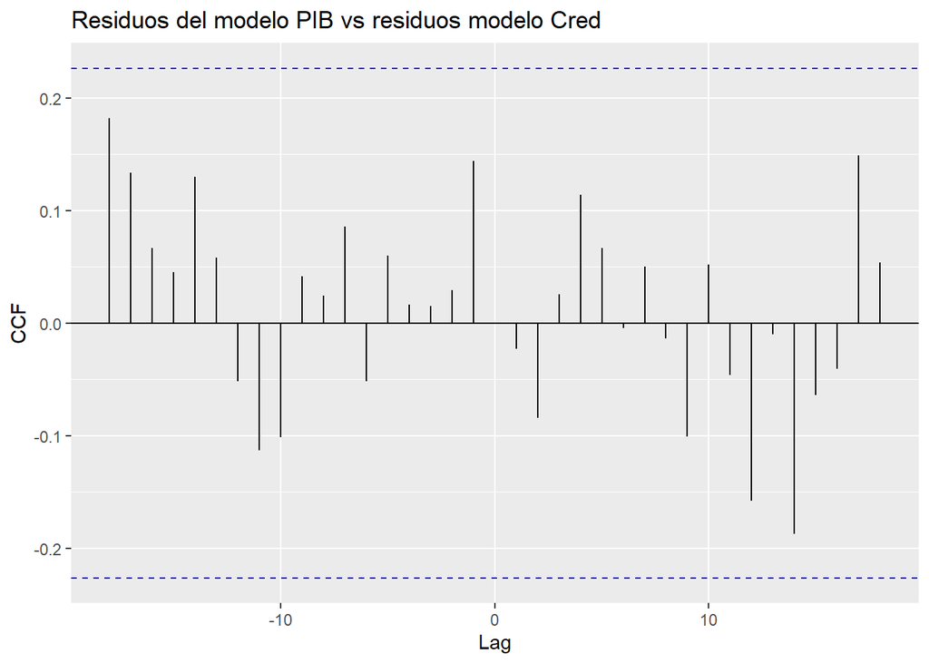

#### 2. Homocedasticidad

Según se constata en la siguiente prueba, el modelo no presenta heterocedasticidad.

```r
arch.test(mod1, lags.multi = 5, multivariate.only = T)
```

```
##
##  ARCH (multivariate)
##
## data:  Residuals of VAR object mod1
## Chi-squared = 43.165, df = 45, p-value = 0.55
```

#### 3. Normalidad del residuo

Los residuos multivariados del modelo siguen una distribución normal.

```r
normality.test(mod1, multivariate.only = T)
```

```
## $JB
##
##  JB-Test (multivariate)
##
## data:  Residuals of VAR object mod1
## Chi-squared = 0.7291, df = 4, p-value = 0.9477
##
##
## $Skewness
##
##  Skewness only (multivariate)
##
## data:  Residuals of VAR object mod1
## Chi-squared = 0.23026, df = 2, p-value = 0.8913
##
##
## $Kurtosis
##
##  Kurtosis only (multivariate)
##
## data:  Residuals of VAR object mod1
## Chi-squared = 0.49884, df = 2, p-value = 0.7793
```

[interactive chart not shown]

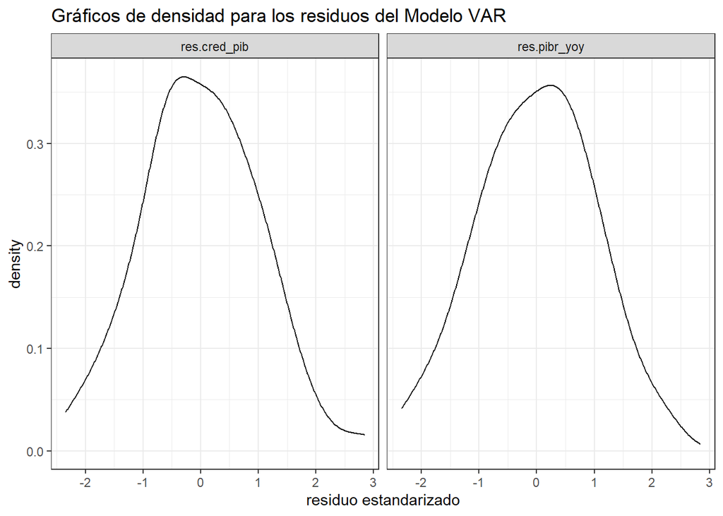

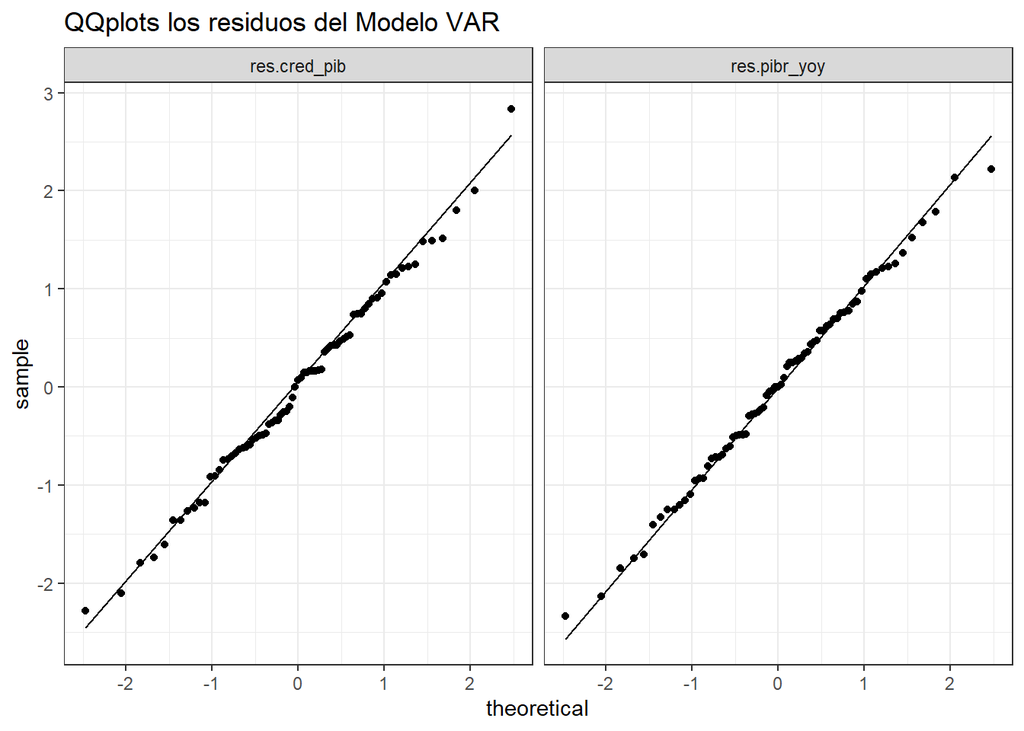

#### 4. Estabilidad

los eigenvalores son menores a 1, por lo cual se concluye que el modelo sí es estable. Esto se reafirma con el gráfico OLS-CUSUM.

```r
roots(mod1, modulus = T)
```

```
##  [1] 0.9627531 0.9627531 0.9417546 0.9417546 0.9330624 0.9143535 0.9143535
##  [8] 0.9080066 0.9080066 0.8935171 0.8935171 0.8931725 0.8931725 0.8658630
## [15] 0.8658630 0.8145871 0.8145871 0.4859090
```

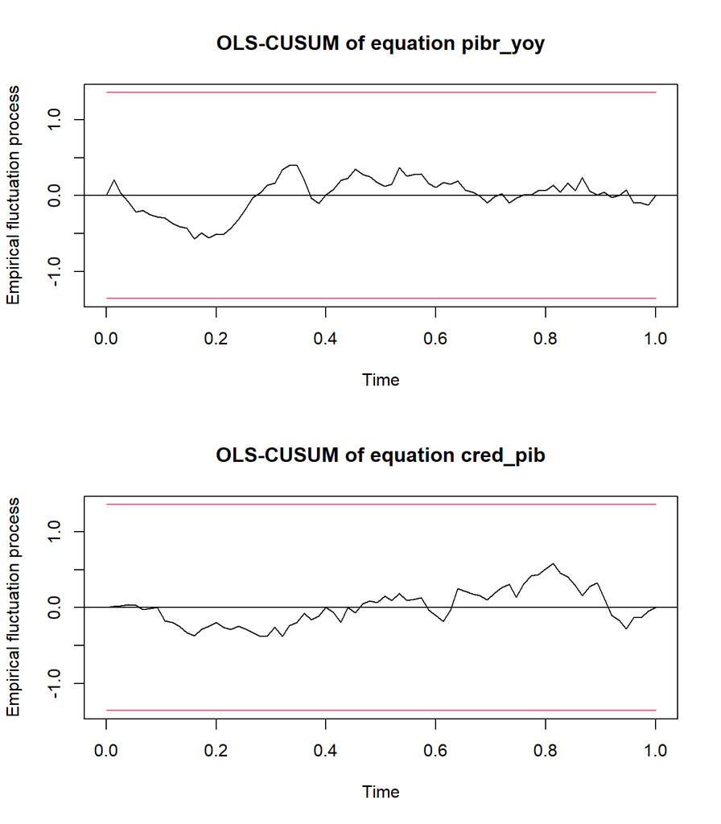

## Modelo VAR 2

**Características del modelo:**

```r
mod2 <- VAR(data %>% dplyr::select(pibr_yoy, cred_pib, mif),
            type = "both",
            lag.max = 8, ic = "AIC",
            exogen = data %>% dplyr::select(apert_comercial, inflacion, ied, pibusa_yoy,
                                            d_2Q04, d_4Q07, d_2Q20))

summary(mod2)
```

```
##
## VAR Estimation Results:
## =========================
## Endogenous variables: pibr_yoy, cred_pib, mif
## Deterministic variables: both
## Sample size: 79
## Log Likelihood: 597.533
## Roots of the characteristic polynomial:
## 0.8738 0.8738 0.8658 0.8658 0.8502 0.8502 0.7911 0.7818 0.7636 0.7636 0.6858 0.6269 0.6269 0.5364 0.5364
## Call:
## VAR(y = data %>% dplyr::select(pibr_yoy, cred_pib, mif), type = "both",
##     exogen = data %>% dplyr::select(apert_comercial, inflacion,
##         ied, pibusa_yoy, d_2Q04, d_4Q07, d_2Q20), lag.max = 8,
##     ic = "AIC")
##
##
## Estimation results for equation pibr_yoy:
## =========================================
## pibr_yoy = pibr_yoy.l1 + cred_pib.l1 + mif.l1 + pibr_yoy.l2 + cred_pib.l2 + mif.l2 + pibr_yoy.l3 + cred_pib.l3 + mif.l3 + pibr_yoy.l4 + cred_pib.l4 + mif.l4 + pibr_yoy.l5 + cred_pib.l5 + mif.l5 + const + trend + apert_comercial + inflacion + ied + pibusa_yoy + d_2Q04 + d_4Q07 + d_2Q20
##
##                   Estimate Std. Error t value Pr(>|t|)
## pibr_yoy.l1      6.203e-01  1.015e-01   6.112 1.06e-07 ***
## cred_pib.l1     -2.289e-01  2.205e-01  -1.038 0.303877
## mif.l1          -5.008e-03  6.499e-03  -0.771 0.444274
## pibr_yoy.l2     -1.867e-02  1.080e-01  -0.173 0.863360
## cred_pib.l2      1.970e-01  3.012e-01   0.654 0.515805
## mif.l2          -4.198e-03  7.161e-03  -0.586 0.560161
## pibr_yoy.l3      2.149e-01  1.263e-01   1.701 0.094571 .
## cred_pib.l3     -2.357e-02  3.081e-01  -0.077 0.939292
## mif.l3           1.505e-03  7.543e-03   0.199 0.842625
## pibr_yoy.l4     -5.524e-01  1.287e-01  -4.291 7.25e-05 ***
## cred_pib.l4     -4.399e-02  3.155e-01  -0.139 0.889630
## mif.l4          -9.308e-04  7.243e-03  -0.129 0.898211
## pibr_yoy.l5      3.227e-01  1.165e-01   2.770 0.007630 **
## cred_pib.l5      4.684e-02  2.042e-01   0.229 0.819422
## mif.l5           5.555e-03  6.416e-03   0.866 0.390326
## const           -1.955e-02  8.805e-02  -0.222 0.825148
## trend           -1.797e-04  3.651e-04  -0.492 0.624453
## apert_comercial  1.396e-03  3.600e-04   3.878 0.000284 ***
## inflacion       -3.643e-03  9.012e-04  -4.043 0.000166 ***
```

[output cut: 87 more lines]

```
## F-statistic: 87.64 on 23 and 55 DF,  p-value: < 2.2e-16
##
##
##
## Covariance matrix of residuals:
##            pibr_yoy   cred_pib        mif
## pibr_yoy  1.438e-04 -1.353e-05  0.0002824
## cred_pib -1.353e-05  3.965e-05 -0.0001316
## mif       2.824e-04 -1.316e-04  0.0298745
##
## Correlation matrix of residuals:
##          pibr_yoy cred_pib     mif
## pibr_yoy   1.0000  -0.1792  0.1362
## cred_pib  -0.1792   1.0000 -0.1209
## mif        0.1362  -0.1209  1.0000
```

### Supuestos del Modelo

#### 1. Autocorrelación serial

```r
serial.test(mod2, lags.pt = 16, type = "PT.asymptotic")
```

```
##
##  Portmanteau Test (asymptotic)
##
## data:  Residuals of VAR object mod2
## Chi-squared = 107.34, df = 99, p-value = 0.2663
```

```r
serial.test(mod2, lags.pt = 16, type = "BG")
```

```
##
##  Breusch-Godfrey LM test
##
## data:  Residuals of VAR object mod2
## Chi-squared = 76.081, df = 45, p-value = 0.002584
```

```r
serial.test(mod2, lags.pt = 16, type = "PT.adjusted")
```

```
##
##  Portmanteau Test (adjusted)
##
## data:  Residuals of VAR object mod2
## Chi-squared = 120.75, df = 99, p-value = 0.06789
```

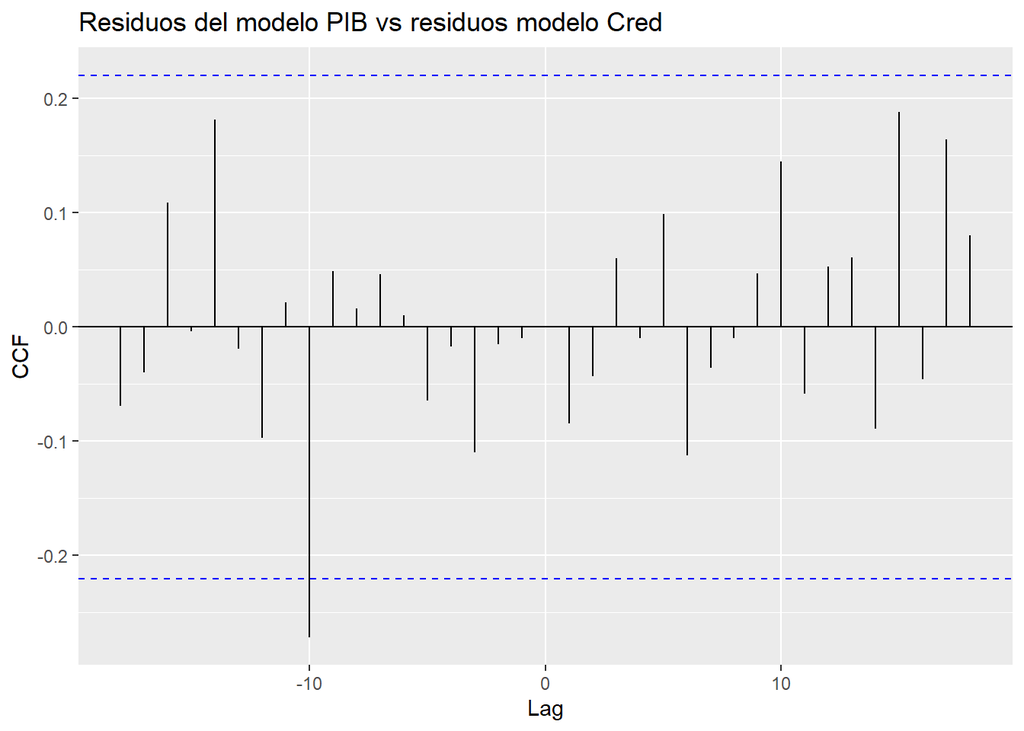

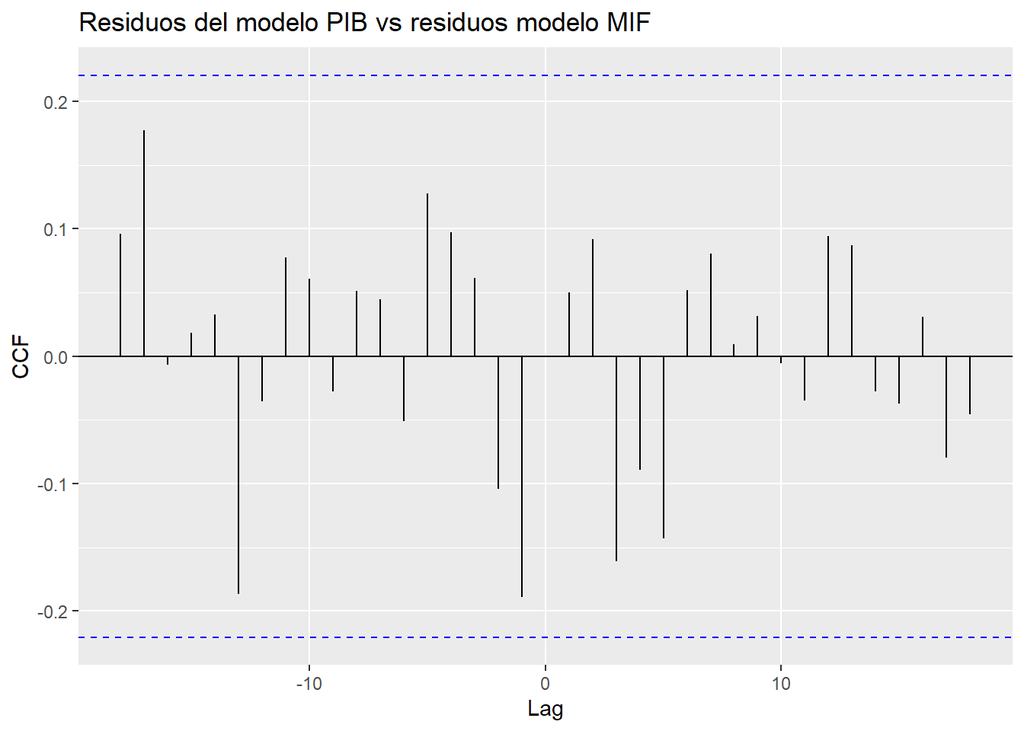

[figure not shown]

#### 2. Homocedasticidad

Según se constata en la siguiente prueba, el modelo no presenta heterocedasticidad.

```r
arch.test(mod2, lags.multi = 5, multivariate.only = T)
```

```
##
##  ARCH (multivariate)
##
## data:  Residuals of VAR object mod2
## Chi-squared = 203.87, df = 180, p-value = 0.1073
```

#### 3. Normalidad del residuo

Los residuos multivariados del modelo siguen una distribución normal.

```r
normality.test(mod2, multivariate.only = T)
```

```
## $JB
##
##  JB-Test (multivariate)
##
## data:  Residuals of VAR object mod2
## Chi-squared = 8.9846, df = 6, p-value = 0.1744
##
##
## $Skewness
##
##  Skewness only (multivariate)
##
## data:  Residuals of VAR object mod2
## Chi-squared = 7.3843, df = 3, p-value = 0.06061
##
##
## $Kurtosis
##
##  Kurtosis only (multivariate)
##
## data:  Residuals of VAR object mod2
## Chi-squared = 1.6003, df = 3, p-value = 0.6593
```

[interactive chart not shown]

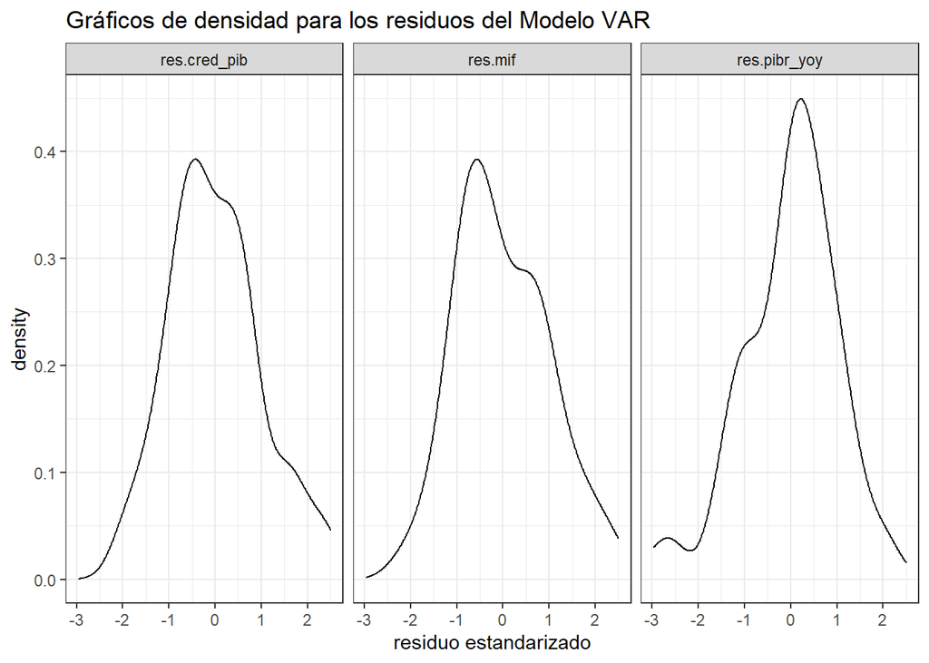

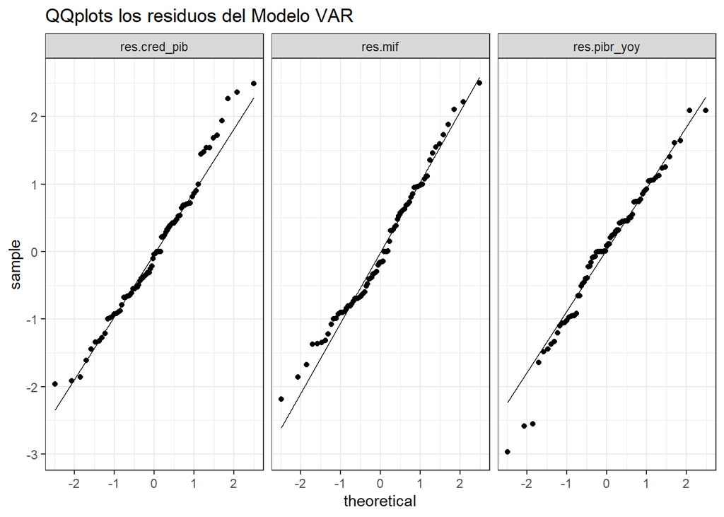

#### 4. Estabilidad

los eigenvalores son menores a 1, por lo cual se concluye que el modelo sí es estable. Esto se reafirma con el gráfico OLS-CUSUM.

```r
roots(mod2, modulus = T)
```

```
##  [1] 0.8738305 0.8738305 0.8657882 0.8657882 0.8502215 0.8502215 0.7911216
##  [8] 0.7817750 0.7636465 0.7636465 0.6858448 0.6269376 0.6269376 0.5363587
## [15] 0.5363587
```

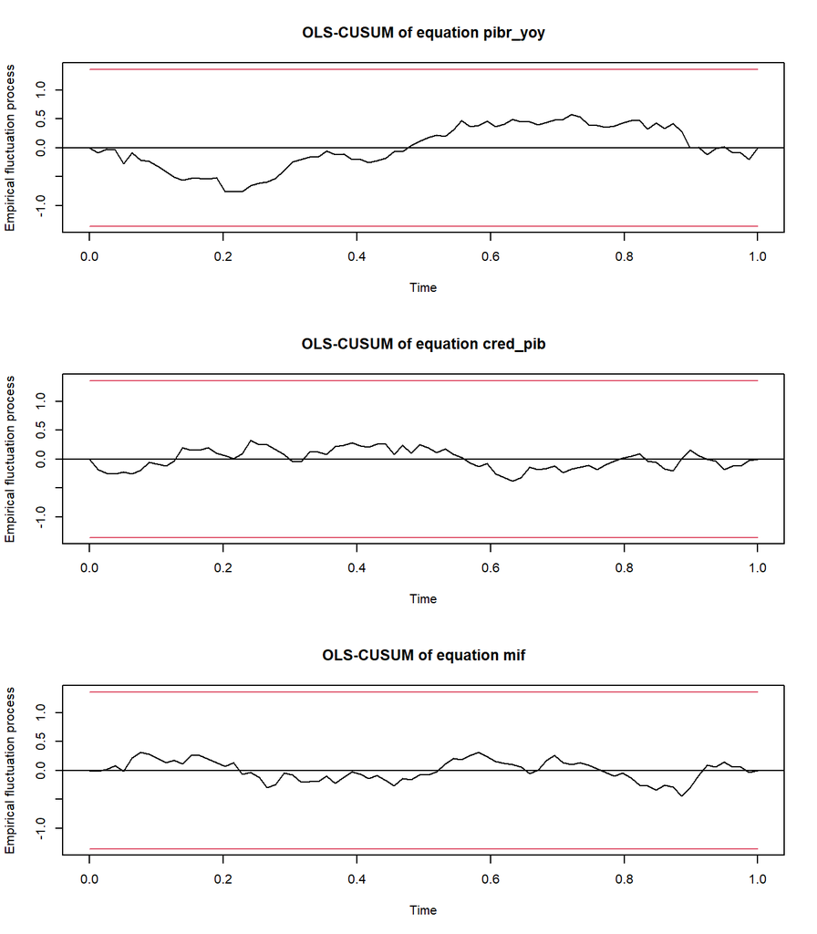

## Modelo VAR 3

**Características del modelo:**

- Incluye 5 variables endógenas: PIBr, Cred, mif (Margen de intermediación financiero), crecimiento interanual del PIB real de USA y la apertura comercial.
- Se definen 5 rezagos, con base al criterio de Akaike.
- Se incluye 3 variable dicotómica para capturar el valor extremo en la variable PIB real asociado a la pandemia y para capturar valores extremos en el modelo del mif.

```r
mod3 <- VAR(data %>% dplyr::select(pibr_yoy, cred_pib, mif, pibusa_yoy, apert_comercial),
            type = "both",
            lag.max = 8, ic = "AIC",
            exogen = data %>% dplyr::select(d_2Q04, d_4Q07, d_2Q20))

summary(mod3)
```

```
##
## VAR Estimation Results:
## =========================
## Endogenous variables: pibr_yoy, cred_pib, mif, pibusa_yoy, apert_comercial
## Deterministic variables: both
## Sample size: 79
## Log Likelihood: 719.831
## Roots of the characteristic polynomial:
## 0.9553 0.9553 0.9399 0.9399 0.905 0.905 0.9018 0.9018 0.8606 0.8606 0.8493 0.8493 0.8492 0.8492 0.8381 0.7227 0.7227 0.7177 0.7177 0.6506 0.5565 0.5565 0.5015 0.5015 0.4199
## Call:
## VAR(y = data %>% dplyr::select(pibr_yoy, cred_pib, mif, pibusa_yoy,
##     apert_comercial), type = "both", exogen = data %>% dplyr::select(d_2Q04,
##     d_4Q07, d_2Q20), lag.max = 8, ic = "AIC")
##
##
## Estimation results for equation pibr_yoy:
## =========================================
## pibr_yoy = pibr_yoy.l1 + cred_pib.l1 + mif.l1 + pibusa_yoy.l1 + apert_comercial.l1 + pibr_yoy.l2 + cred_pib.l2 + mif.l2 + pibusa_yoy.l2 + apert_comercial.l2 + pibr_yoy.l3 + cred_pib.l3 + mif.l3 + pibusa_yoy.l3 + apert_comercial.l3 + pibr_yoy.l4 + cred_pib.l4 + mif.l4 + pibusa_yoy.l4 + apert_comer…
##
##                      Estimate Std. Error t value Pr(>|t|)
## pibr_yoy.l1         0.4756453  0.1431729   3.322 0.001694 **
## cred_pib.l1        -0.0525871  0.2532854  -0.208 0.836386
## mif.l1              0.0007880  0.0078171   0.101 0.920115
## pibusa_yoy.l1       0.6501192  0.1762903   3.688 0.000567 ***
## apert_comercial.l1 -0.0002117  0.0005706  -0.371 0.712288
## pibr_yoy.l2         0.3247871  0.1546550   2.100 0.040893 *
## cred_pib.l2         0.1988366  0.3508495   0.567 0.573485
## mif.l2             -0.0094904  0.0082738  -1.147 0.256932
## pibusa_yoy.l2      -0.4255192  0.1898850  -2.241 0.029595 *
## apert_comercial.l2 -0.0003545  0.0006389  -0.555 0.581561
## pibr_yoy.l3         0.3210021  0.1556285   2.063 0.044470 *
## cred_pib.l3        -0.1452102  0.3567057  -0.407 0.685717
## mif.l3              0.0087452  0.0082684   1.058 0.295393
## pibusa_yoy.l3      -0.1882280  0.3933419  -0.479 0.634398
## apert_comercial.l3 -0.0002011  0.0006295  -0.319 0.750800
## pibr_yoy.l4        -0.6756071  0.1593294  -4.240 9.85e-05 ***
## cred_pib.l4        -0.2766737  0.3550250  -0.779 0.439546
## mif.l4              0.0052444  0.0085282   0.615 0.541436
## pibusa_yoy.l4      -0.2772228  0.3897479  -0.711 0.480279
## apert_comercial.l4  0.0005259  0.0006495   0.810 0.422034
```

[output cut: 196 more lines]

```
## Covariance matrix of residuals:
##                   pibr_yoy   cred_pib        mif pibusa_yoy apert_comercial
## pibr_yoy         1.709e-04 -1.309e-05  5.040e-04  3.969e-05        0.016008
## cred_pib        -1.309e-05  4.715e-05 -1.531e-04 -1.505e-05        0.001532
## mif              5.040e-04 -1.531e-04  3.234e-02  4.588e-05        0.101588
## pibusa_yoy       3.969e-05 -1.505e-05  4.588e-05  7.305e-05        0.009932
## apert_comercial  1.601e-02  1.532e-03  1.016e-01  9.932e-03        8.901075
##
## Correlation matrix of residuals:
##                 pibr_yoy cred_pib      mif pibusa_yoy apert_comercial
## pibr_yoy          1.0000  -0.1458  0.21437    0.35516          0.4104
## cred_pib         -0.1458   1.0000 -0.12403   -0.25652          0.0748
## mif               0.2144  -0.1240  1.00000    0.02985          0.1894
## pibusa_yoy        0.3552  -0.2565  0.02985    1.00000          0.3895
## apert_comercial   0.4104   0.0748  0.18936    0.38951          1.0000
```

### Supuestos del Modelo

#### 1. Autocorrelación serial

```r
serial.test(mod3, lags.pt = 16, type = "PT.asymptotic")
```

```
##
##  Portmanteau Test (asymptotic)
##
## data:  Residuals of VAR object mod3
## Chi-squared = 309.89, df = 275, p-value = 0.0725
```

```r
serial.test(mod3, lags.pt = 16, type = "BG")
```

```
##
##  Breusch-Godfrey LM test
##
## data:  Residuals of VAR object mod3
## Chi-squared = 212.57, df = 125, p-value = 1.704e-06
```

```r
serial.test(mod3, lags.pt = 16, type = "PT.adjusted")
```

```
##
##  Portmanteau Test (adjusted)
##
## data:  Residuals of VAR object mod3
## Chi-squared = 349.79, df = 275, p-value = 0.001507
```

#### 2. Homocedasticidad

Según se constata en la siguiente prueba, el modelo no presenta heterocedasticidad.

```r
arch.test(mod3, lags.multi = 5, multivariate.only = T)
```

```
##
##  ARCH (multivariate)
##
## data:  Residuals of VAR object mod3
## Chi-squared = 1110, df = 1125, p-value = 0.6193
```

#### 3. Normalidad del residuo

Los residuos multivariados del modelo siguen una distribución normal.

```r
normality.test(mod3, multivariate.only = T)
```

```
## $JB
##
##  JB-Test (multivariate)
##
## data:  Residuals of VAR object mod3
## Chi-squared = 12.14, df = 10, p-value = 0.2758
##
##
## $Skewness
##
##  Skewness only (multivariate)
##
## data:  Residuals of VAR object mod3
## Chi-squared = 7.9407, df = 5, p-value = 0.1595
##
##
## $Kurtosis
##
##  Kurtosis only (multivariate)
##
## data:  Residuals of VAR object mod3
## Chi-squared = 4.1993, df = 5, p-value = 0.5211
```

[interactive chart not shown]

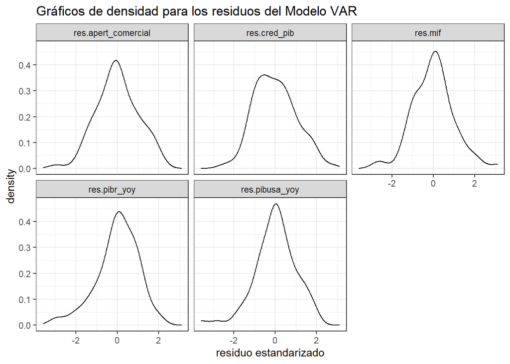

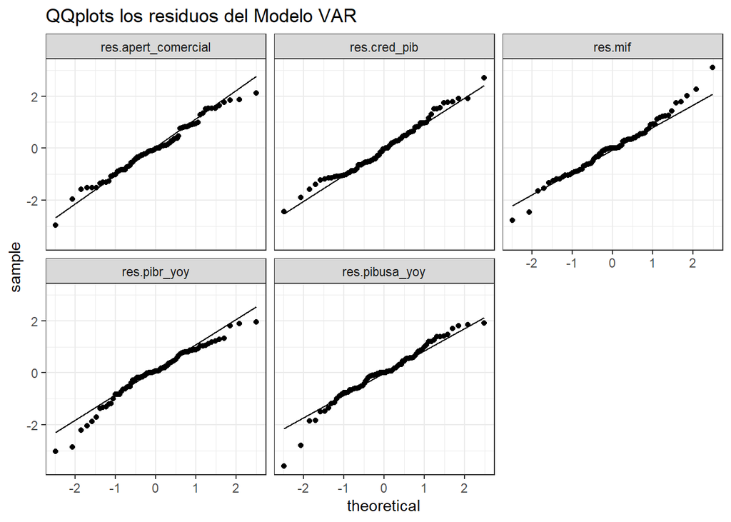

#### 4. Estabilidad

los eigenvalores son menores a 1, por lo cual se concluye que el modelo sí es estable. Esto se reafirma con el gráfico OLS-CUSUM.

```r
roots(mod3, modulus = T)
```

```
##  [1] 0.9552661 0.9552661 0.9398529 0.9398529 0.9049711 0.9049711 0.9017555
##  [8] 0.9017555 0.8606397 0.8606397 0.8492902 0.8492902 0.8492263 0.8492263
## [15] 0.8381411 0.7227290 0.7227290 0.7177464 0.7177464 0.6506188 0.5565120
## [22] 0.5565120 0.5014544 0.5014544 0.4199055
```

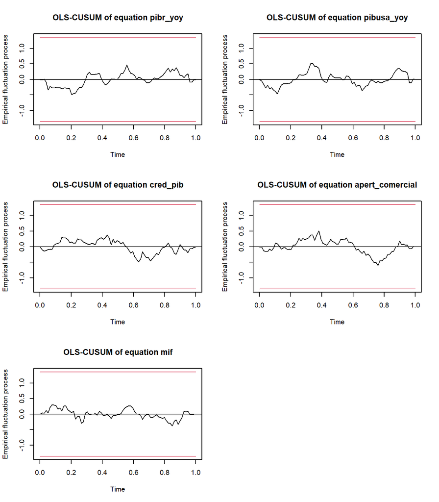

## Funciones impulso-respuesta

### PIBr

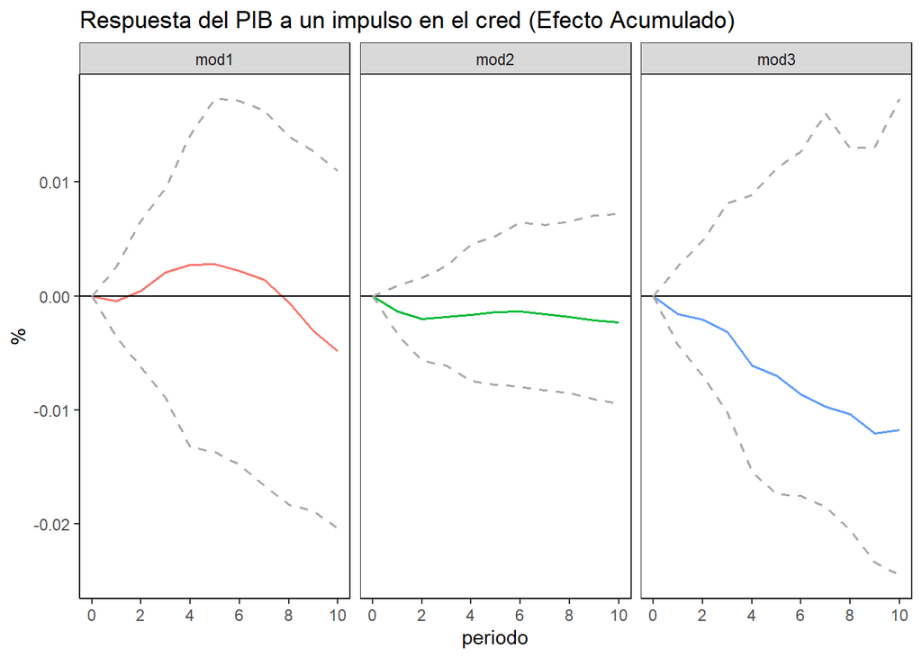

### Cred

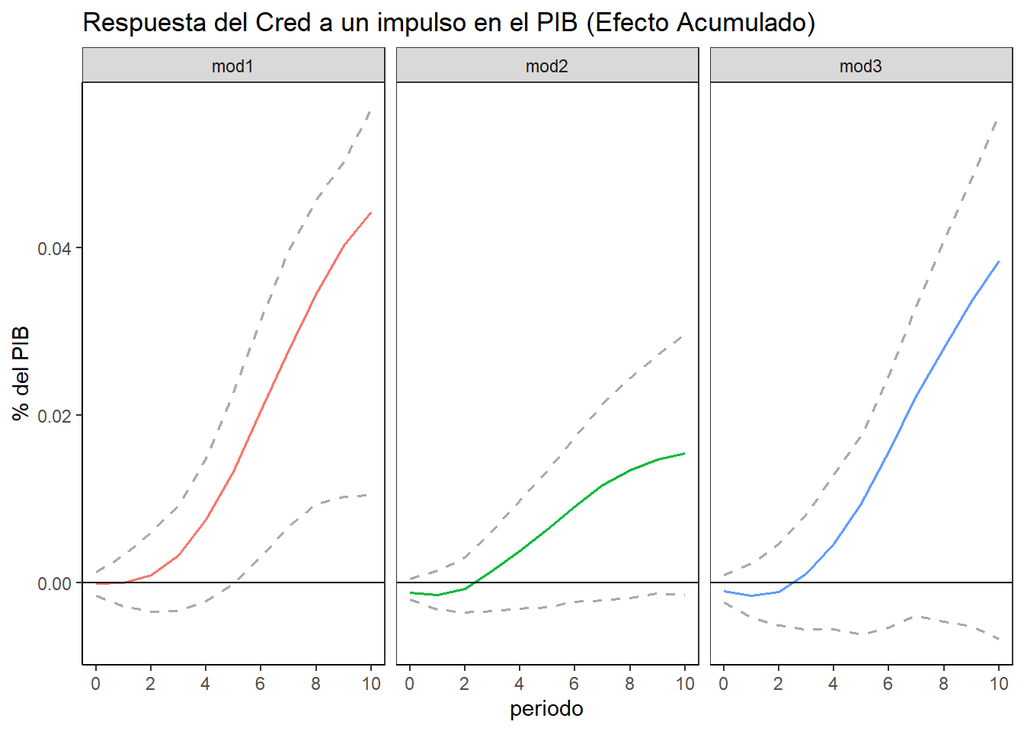

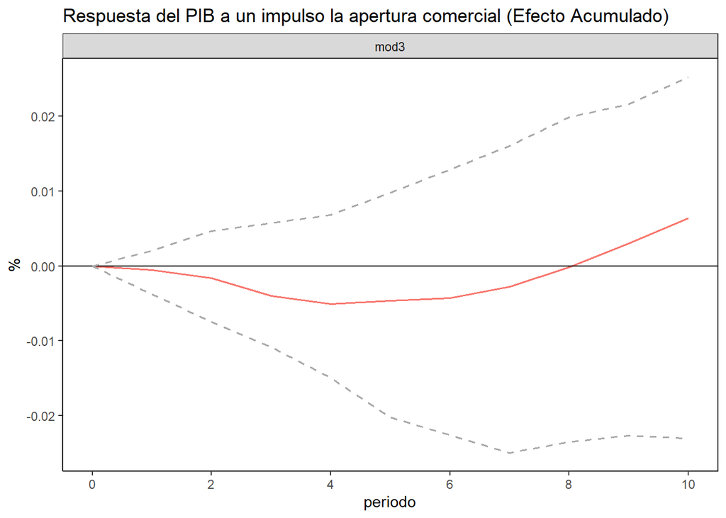

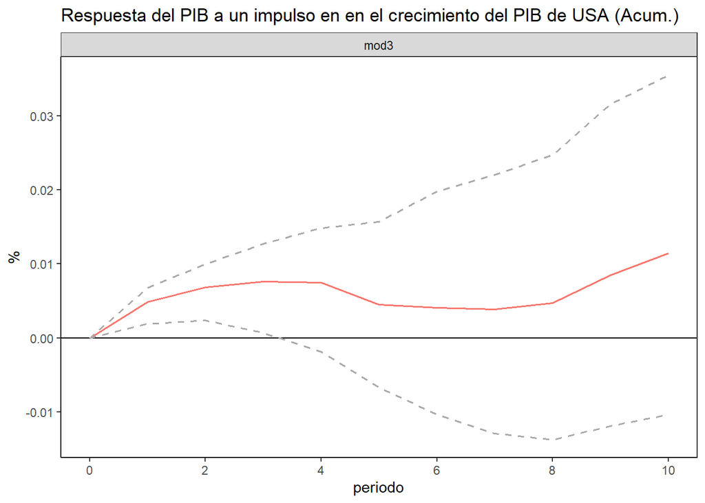